# Segunda sesión de laboratorio

22/02/2015

## Tratamiento 1

- Dos empresas sirven el mercado de un producto homogéneo.
- Cada unidad producida tiene un coste unitario de \(200\ €\).
- Cada periodo se divide en dos etapas:
  - La empresa líder decide cuántas unidades va a producir.
  - La empresa seguidora decide su producción *conociendo la decisión de la líder*.
- La demanda determina el precio al que se venden todas las unidades.

## Costes

- El coste unitario es independiente de la producción: \[ CMe_1(q_1) = CMe_2(q_2) = 200 \]
- Los costes de cada una de las empresas son: \[ C_1(q_1) = 200 q_1; \qquad C_2(q_2) = 200 q_2 \]
- El coste marginal coincide con el coste unitario: \[ CMg_1(q_1) = \frac{\mathrm{d}\; C_1(q_1)}{\mathrm{d}\; q_1} = 200; \quad CMg_2(q_2) = 200 \]

## Demanda

- La curva inversa de demanda del mercado es: \[ P = 500 - \frac{1}{2} Q \]
- La producción total, \(Q\), es la suma de las producciones de cada empresa: \[ Q = q_1 + q_2 \]
- Por tanto: \[ P = 500 - \frac{1}{2} (q_1 + q_2) \]

## Ingresos

- Los ingresos de la empresa \(2\) son: \[ I_2(q_2) = P q_2 \]
- Sustituyendo la curva de demanda en la expresión anterior: \[ I_2(q_2) = \Big(500 - \frac{q_1}{2} - \frac{q_2}{2}\Big) q_2 \]
- Ingreso marginal de la empresa 2: \[ IMg_2(q_2) = \frac{\mathrm{d}\; I_2(q_2)}{\mathrm{d}\; q_2} = 500 - \frac{q_1}{2} - q_2 \]

## Producción del seguidor

- Condición de primer orden para la maximización del beneficio: \[ IMg_2(q_2^*) = CMg_2(q_2^*) \]
- En nuestro caso: \[ 500 - \frac{q_1}{2} - q_2^* = 200 \]
- Función de reacción del seguidor: \[ q_2^* = 300 - \frac{q_1}{2} \]

## Ingresos del líder

- Sustituimos la reacción del seguidor en la curva de demanda: \[ P = 500 -\frac{1}{2}(q_1 + 300 - \frac{1}{2} q_1) = 350 -\frac{1}{4} q_1 \]
- Los ingresos del líder son: \[ I_1(q_1) = P q_1 = 350 q_1 - \frac{1}{4} q_1^2 \]
- Ingreso marginal de la empresa 1: \[ IMg_1(q_1) = \frac{\mathrm{d}\; I_1(q_1)}{\mathrm{d}\; q_1} = 350 - \frac{1}{2} q_1 \]

## Producción del líder

- Condición de primer orden para la maximización del beneficio: \[ IMg_1(q_1^*) = CMg_1(q_1^*) \]
- En nuestro caso: \[ 350 - \frac{q_1^*}{2} = 200 \]
- Por tanto: \[ q_1^* = 300\ \text{u.} \]

## Equilibrio: producción

- El líder produce \(q^*_1 = 300\) unidades.
- La reacción óptima del seguidor es: \[ q^*_2 = 300 - q^*_1 /2 = 150\ \text{unidades.} \]
- La producción de mercado es \[ Q^* = q^*_1 + q^*_2 = 300 + 150 = 450\ \text{unidades.} \]

## Equilibrio: precios y beneficios

- La demanda determina el precio: \[ P^* = 500 - Q^*/2 = 500 - 450/2 = 275\ \text{€/u.} \]
- El beneficio del líder es \[ \pi_1 = (P^* - CMe) q^*_1 = (275 - 200) \times 300 = 22500\ \text{€}. \]
- El beneficio del líder es \[ \pi_2 = (P^* - CMe) q^*_2 = (275 - 200) \times 150 = 11250\ \text{€}. \]

## Resultados del laboratorio

- Sesiones del 16 de febrero (grupo F) y 17 de febrero (grupo A) de 2015.
- Cada tratamiento estaba compuesto por 7 periodos.
- Número de sujetos: 84.

## Estadísticos descriptivos

### Producción del líder

| Period | Mean | SD | Min | 25% | Median | 75% | Max |
| --- | --- | --- | --- | --- | --- | --- | --- |
| 1 | 296.2 | 102.1 | 0 | 300.0 | 300.0 | 350.0 | 425 |
| 2 | 275.0 | 94.6 | 0 | 250.0 | 290.0 | 345.0 | 500 |
| 3 | 281.1 | 101.4 | 0 | 230.0 | 300.0 | 350.0 | 500 |
| 4 | 265.4 | 75.8 | 100 | 225.0 | 267.5 | 300.0 | 450 |
| 5 | 256.2 | 68.5 | 0 | 232.5 | 265.0 | 300.0 | 350 |
| 6 | 253.4 | 78.5 | 120 | 207.5 | 250.0 | 287.5 | 500 |
| 7 | 267.0 | 68.3 | 90 | 246.2 | 275.0 | 300.0 | 500 |

## Estadísticos descriptivos

### Producción del seguidor

| Period | Mean | SD | Min | 25% | Median | 75% | Max |
| --- | --- | --- | --- | --- | --- | --- | --- |
| 1 | 247.0 | 113.6 | 0 | 200 | 262.5 | 300 | 460 |
| 2 | 224.0 | 101.0 | 0 | 200 | 250.0 | 280 | 370 |
| 3 | 236.1 | 82.4 | 0 | 200 | 260.0 | 300 | 350 |
| 4 | 239.9 | 84.0 | 0 | 200 | 247.0 | 290 | 500 |
| 5 | 228.8 | 67.3 | 60 | 200 | 240.0 | 275 | 370 |
| 6 | 234.9 | 87.5 | 0 | 200 | 250.0 | 280 | 500 |
| 7 | 231.8 | 103.9 | 0 | 200 | 250.0 | 300 | 450 |

## Distribución de la producción

### Empresa líder

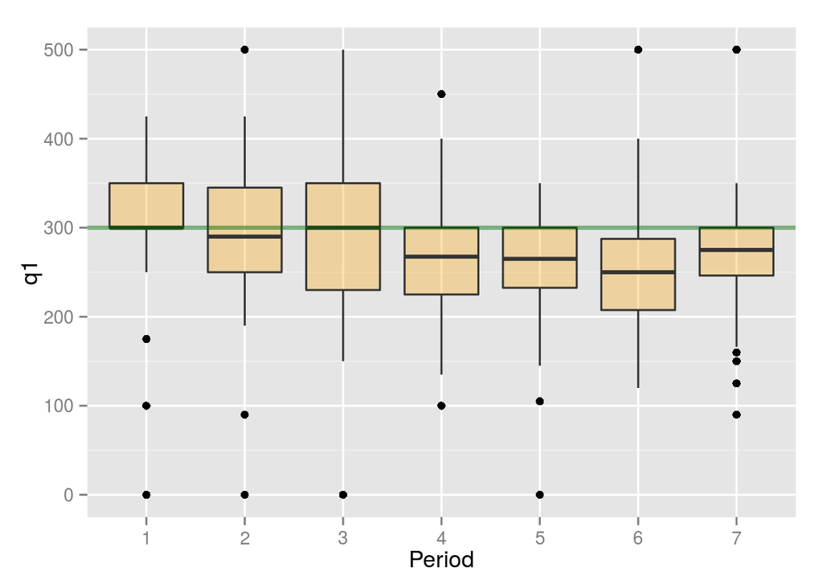

## Distribución de la producción

### Empresa seguidora

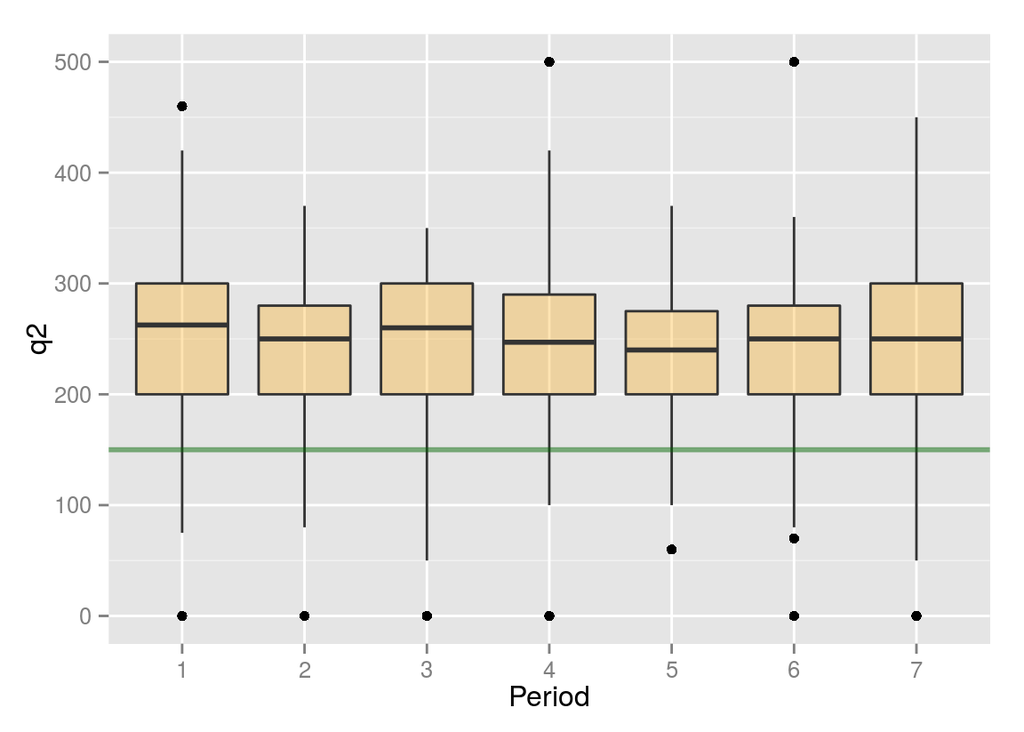

## Comparación de las cantidades

### Diferencia de las producciones del líder y del seguidor

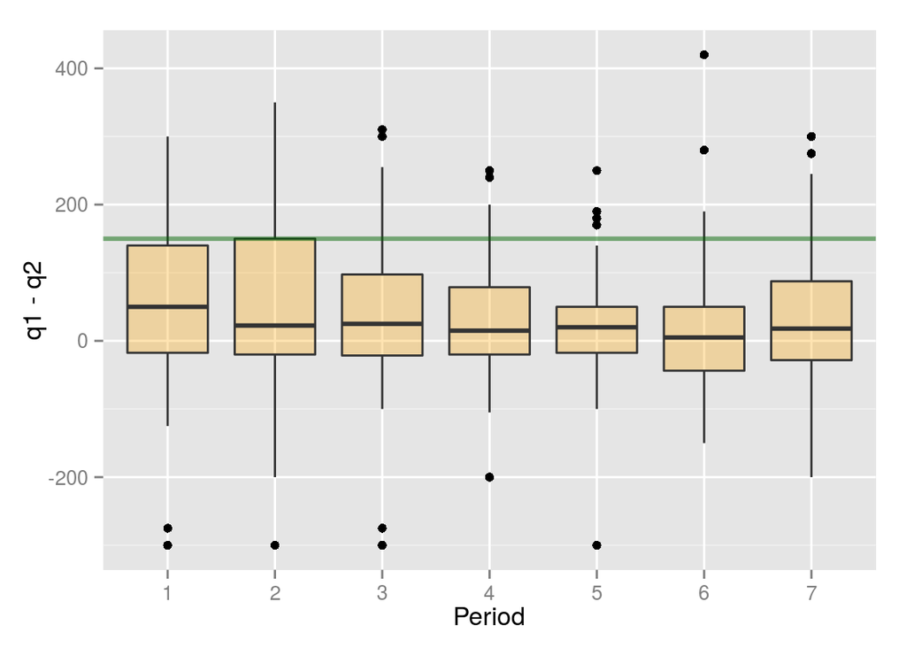

## Comparación de las cantidades

### Producciones del líder y del seguidor

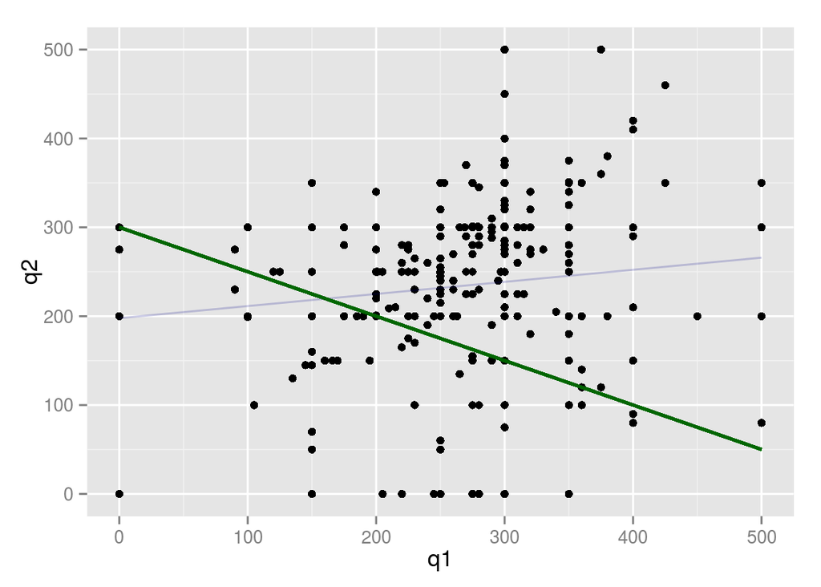

## Comparación de las cantidades

### Correlación de las producciones por período

| Period | rho |
| --- | --- |
| 1 | 0.28 |
| 2 | -0.04 |
| 3 | -0.05 |
| 4 | 0.25 |
| 5 | 0.10 |
| 6 | 0.14 |
| 7 | 0.17 |

## Tratamiento 2

- Dos empresas sirven el mercado de un producto homogéneo.
- Cada unidad producida tiene un coste unitario de \(200\ €\).
- Cada periodo las empresas deciden simultáneamente cuántas unidades va a producir.
- La demanda determina el precio al que se venden todas las unidades.

## La elección del nivel de producción

- Funciones de reacción: \[ \begin{gather*} q_1^* = 300 - \frac{q_2}{2} \\ q_2^* = 300 - \frac{q_1}{2} \end{gather*} \]
- La primera ecuación expresa la producción que maximiza los beneficios de la empresa 1 *si la empresa 2 produce \(q_2\)*.
- La segunda ecuación expresa la producción que maximiza los beneficios de la empresa 2 *si la empresa 1 produce \(q_1\)*.

## Equilibrio de Nash

- En equilibrio la producción de cada una de las empresas es la mejor respuesta a las decisiones de producción de sus rivales. \[ \begin{gather*} q_1^* = 300 - \frac{q^*_2}{2} \\ q_2^* = 300 - \frac{q^*_1}{2} \end{gather*} \]
- En equilibrio \(q^*_1 = q^*_2 = 200\) unidades.
- El precio de equilibrio es \(P^* = 500 - 400/2 = 300\) €/u.
- Los beneficios son \(\pi^*_1 = \pi^*_2 = 20000\) €.

## Estadísticos descriptivos

### Producción de las empresas

| Period | Mean | SD | Min | 25% | Median | 75% | Max |
| --- | --- | --- | --- | --- | --- | --- | --- |
| 1 | 252.7 | 59.6 | 0 | 225.0 | 250.0 | 300 | 350 |
| 2 | 271.5 | 57.2 | 150 | 250.0 | 275.0 | 300 | 400 |
| 3 | 261.0 | 65.2 | 25 | 225.0 | 269.0 | 300 | 500 |
| 4 | 250.4 | 68.0 | 0 | 240.0 | 255.0 | 290 | 350 |
| 5 | 259.8 | 51.7 | 85 | 248.8 | 265.0 | 300 | 370 |
| 6 | 252.5 | 59.8 | 0 | 215.0 | 260.0 | 300 | 350 |
| 7 | 260.1 | 68.7 | 50 | 228.8 | 257.5 | 300 | 500 |

## Distribución de las cantidades

### Producción de las empresas

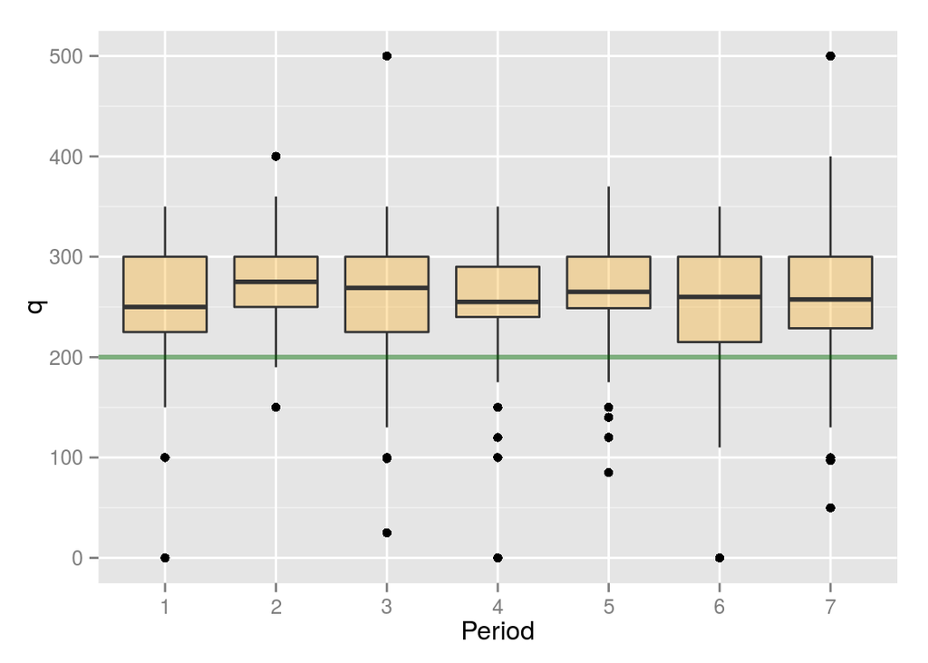